# Acoustics and articulation relations in jaw movement

2024-02-17

# PART 1 - Distance of extreme points from the AVO

#### Table 1. Frequency with which the extreme point was the closest to the AVO

|  | Freq | % |
| --- | --- | --- |
| **maxDisp** | 54 | 7.18 |
| **maxVel** | 10 | 1.33 |
| **minVel** | 484 | 64.36 |
| **maxAcc** | 170 | 22.61 |
| **minAcc** | 34 | 4.52 |
| **Total** | 752 | 100.00 |

Now, without Mark:

|  | Freq | % |
| --- | --- | --- |
| **maxDisp** | 19 | 4.08 |
| **maxVel** | 1 | 0.21 |
| **minVel** | 371 | 79.61 |
| **maxAcc** | 44 | 9.44 |
| **minAcc** | 31 | 6.65 |
| **Total** | 466 | 100.00 |

#### Table 2. Descriptive statistics of the distances of extreme points from the AVO

| point_type | mean | sd | median |
| --- | --- | --- | --- |
| maxDisp | 0.059 | 0.052 | 0.065 |
| maxVel | 0.02 | 0.124 | 0.088 |
| minVel | -0.012 | 0.041 | -0.009 |
| maxAcc | 0.052 | 0.043 | 0.059 |
| minAcc | -0.063 | 0.07 | -0.075 |

#### Figure 1. Distribution of the distances of extreme points from the AVO

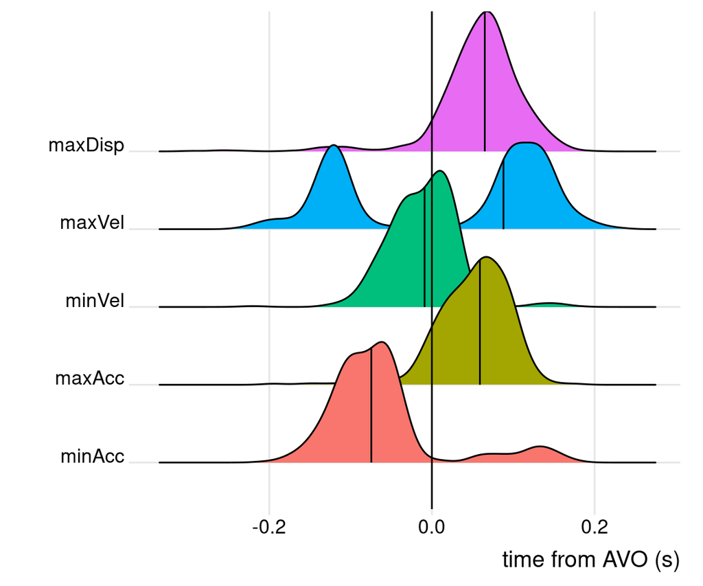

#### Table 3. Frequency with which the extreme point was the closest to the AVO according to speakers

|  | nearest | maxDisp | maxVel | minVel | maxAcc | minAcc | Total |
| --- | --- | --- | --- | --- | --- | --- | --- |
| speaker |  |  |  |  |  |  |  |
| Lauren |  | 11 ( 4.331%) | 0 (0.000%) | 204 (80.315%) | 19 ( 7.480%) | 20 (7.874%) | 254 (100.000%) |
| Mark |  | 35 (12.238%) | 9 (3.147%) | 113 (39.510%) | 126 (44.056%) | 3 (1.049%) | 286 (100.000%) |
| Ian |  | 8 ( 3.774%) | 1 (0.472%) | 167 (78.774%) | 25 (11.792%) | 11 (5.189%) | 212 (100.000%) |
| Total |  | 54 ( 7.181%) | 10 (1.330%) | 484 (64.362%) | 170 (22.606%) | 34 (4.521%) | 752 (100.000%) |

#### Table 4. Descriptive statistics of the distances of extreme points from the AVO according to speaker

| point_type | speaker | mean | sd | median |
| --- | --- | --- | --- | --- |
| maxDisp | Lauren | 0.078 | 0.051 | 0.077 |
| maxDisp | Mark | 0.043 | 0.05 | 0.048 |
| maxDisp | Ian | 0.059 | 0.05 | 0.071 |
| maxVel | Lauren | -0.019 | 0.127 | -0.106 |
| maxVel | Mark | 0.068 | 0.104 | 0.096 |
| maxVel | Ian | 0.001 | 0.125 | -0.068 |
| minVel | Lauren | 0.004 | 0.028 | 0.009 |
| minVel | Mark | -0.033 | 0.048 | -0.037 |
| minVel | Ian | -0.003 | 0.033 | 0.004 |
| maxAcc | Lauren | 0.074 | 0.032 | 0.077 |
| maxAcc | Mark | 0.023 | 0.042 | 0.024 |
| maxAcc | Ian | 0.065 | 0.034 | 0.07 |
| minAcc | Lauren | -0.068 | 0.03 | -0.062 |
| minAcc | Mark | -0.056 | 0.103 | -0.102 |
| minAcc | Ian | -0.065 | 0.044 | -0.066 |

#### Figure 2. Distribution of the distances of extreme points from the AVO according to speaker

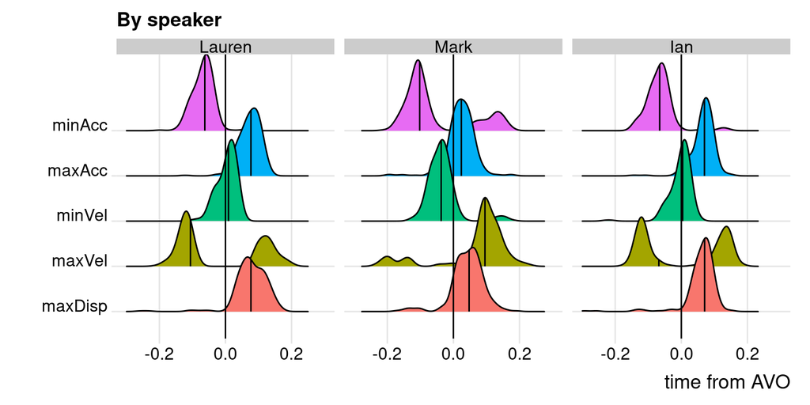

#### Table 5. Frequency with which the extreme point was the closest to the AVO according to emphasis

|  | nearest | maxDisp | maxVel | minVel | maxAcc | minAcc | Total |
| --- | --- | --- | --- | --- | --- | --- | --- |
| emph |  |  |  |  |  |  |  |
| emphasized |  | 2 (3.226%) | 0 (0.000%) | 44 (70.968%) | 11 (17.742%) | 5 (8.065%) | 62 (100.000%) |
| not emphasized |  | 52 (7.536%) | 10 (1.449%) | 440 (63.768%) | 159 (23.043%) | 29 (4.203%) | 690 (100.000%) |
| Total |  | 54 (7.181%) | 10 (1.330%) | 484 (64.362%) | 170 (22.606%) | 34 (4.521%) | 752 (100.000%) |

#### Table 6. Descriptive statistics of the distances of extreme points from the AVO according to emphasis

| point_type | emph | mean | sd | median |
| --- | --- | --- | --- | --- |
| maxDisp | emphasized | 0.081 | 0.05 | 0.088 |
| maxDisp | not emphasized | 0.057 | 0.052 | 0.063 |
| maxVel | emphasized | 0.041 | 0.148 | 0.126 |
| maxVel | not emphasized | 0.018 | 0.122 | 0.086 |
| minVel | emphasized | -0.013 | 0.044 | 0.002 |
| minVel | not emphasized | -0.012 | 0.041 | -0.011 |
| maxAcc | emphasized | 0.067 | 0.05 | 0.079 |
| maxAcc | not emphasized | 0.051 | 0.042 | 0.056 |
| minAcc | emphasized | -0.069 | 0.069 | -0.07 |
| minAcc | not emphasized | -0.062 | 0.07 | -0.075 |

#### Figure 3. Distribution of the distances of extreme points from the AVO according to emphasis

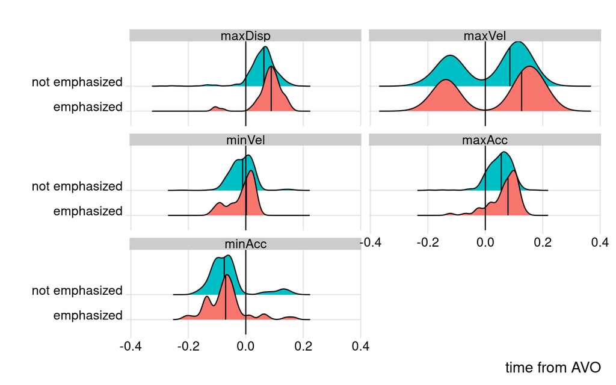

#### Table 7. Frequency with which the extreme point was the closest to the AVO according to word (only emphasized occurances)

|  | nearest | maxDisp | maxVel | minVel | maxAcc | minAcc | Total |
| --- | --- | --- | --- | --- | --- | --- | --- |
| word |  |  |  |  |  |  |  |
| THAT |  | 0 ( 0.000%) | 0 (0.000%) | 15 (100.000%) | 0 ( 0.000%) | 0 ( 0.000%) | 15 (100.000%) |
| CAT |  | 2 (11.765%) | 0 (0.000%) | 2 ( 11.765%) | 11 (64.706%) | 2 (11.765%) | 17 (100.000%) |
| BAT |  | 0 ( 0.000%) | 0 (0.000%) | 15 (100.000%) | 0 ( 0.000%) | 0 ( 0.000%) | 15 (100.000%) |
| FAT |  | 0 ( 0.000%) | 0 (0.000%) | 12 ( 80.000%) | 0 ( 0.000%) | 3 (20.000%) | 15 (100.000%) |
| Total |  | 2 ( 3.226%) | 0 (0.000%) | 44 ( 70.968%) | 11 (17.742%) | 5 ( 8.065%) | 62 (100.000%) |

#### Table 8. Descriptive statistics of the distances of extreme points from the AVO according to word (only emphasized occurances)

| point_type | word | mean | sd | median |
| --- | --- | --- | --- | --- |
| maxDisp | THAT | 0.095 | 0.022 | 0.1 |
| maxDisp | CAT | 0.065 | 0.03 | 0.065 |
| maxDisp | BAT | 0.117 | 0.027 | 0.119 |
| maxDisp | FAT | 0.05 | 0.077 | 0.083 |
| maxVel | THAT | -0.017 | 0.138 | -0.12 |
| maxVel | CAT | 0.153 | 0.039 | 0.157 |
| maxVel | BAT | -0.042 | 0.164 | -0.137 |
| maxVel | FAT | 0.057 | 0.148 | 0.141 |
| minVel | THAT | 0.008 | 0.027 | 0.023 |
| minVel | CAT | -0.071 | 0.036 | -0.086 |
| minVel | BAT | 0.007 | 0.014 | 0.007 |
| minVel | FAT | 0.012 | 0.02 | 0.013 |
| maxAcc | THAT | 0.086 | 0.025 | 0.098 |
| maxAcc | CAT | 0.021 | 0.048 | 0.016 |
| maxAcc | BAT | 0.097 | 0.023 | 0.096 |
| maxAcc | FAT | 0.07 | 0.057 | 0.079 |
| minAcc | THAT | -0.071 | 0.037 | -0.054 |
| minAcc | CAT | -0.056 | 0.123 | -0.133 |
| minAcc | BAT | -0.086 | 0.028 | -0.076 |
| minAcc | FAT | -0.065 | 0.025 | -0.067 |

#### Figure 4. Distribution of the distances of extreme points from the AVO according to word (only emphasized occurences)

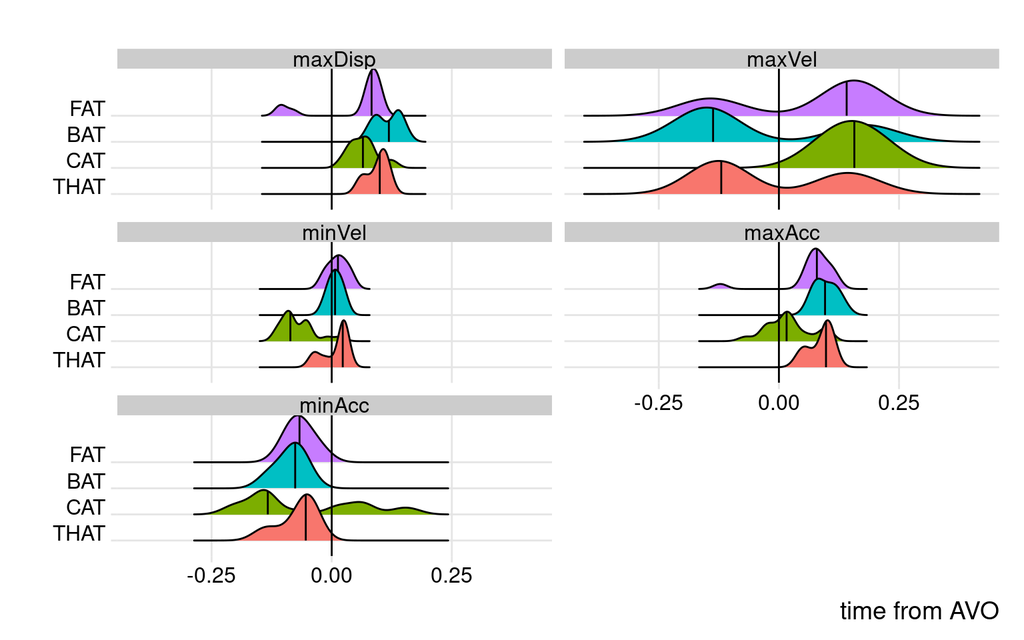

# Part 2: Amplitude of the signal at the AVO when this signal’s extreme point is the closest to the AVO

#### Table 9. Descriptive statistics

| nearest | mean | sd | median |
| --- | --- | --- | --- |
| maxDisp | -0.3 | 0.34 | -0.33 |
| maxVel | 0.061 | 0.017 | 0.062 |
| minVel | -0.045 | 0.024 | -0.04 |
| maxAcc | 0.24 | 0.11 | 0.25 |
| minAcc | -0.18 | 0.15 | -0.15 |

#### Figure 5. Density plots

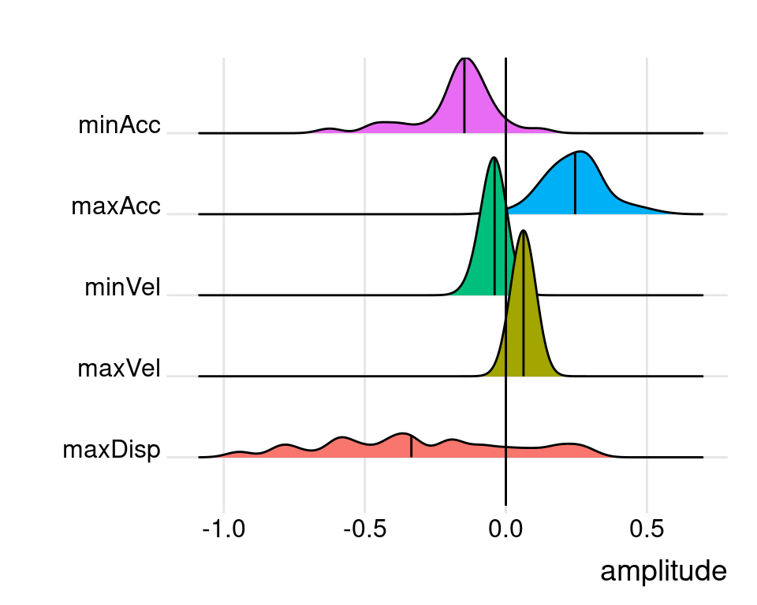

#### Table 10. Descriptive statistics relative to emphasis

| nearest | emph | mean | sd | median |
| --- | --- | --- | --- | --- |
| maxDisp | emphasized | -0.94 | 0.022 | -0.94 |
| maxDisp | not emphasized | -0.28 | 0.32 | -0.33 |
| maxVel | not emphasized | 0.061 | 0.017 | 0.062 |
| minVel | emphasized | -0.068 | 0.028 | -0.056 |
| minVel | not emphasized | -0.043 | 0.022 | -0.038 |
| maxAcc | emphasized | 0.23 | 0.087 | 0.23 |
| maxAcc | not emphasized | 0.24 | 0.11 | 0.25 |
| minAcc | emphasized | -0.045 | 0.11 | -0.1 |
| minAcc | not emphasized | -0.2 | 0.14 | -0.17 |

#### Figure 6. Density plots relative to emphasis

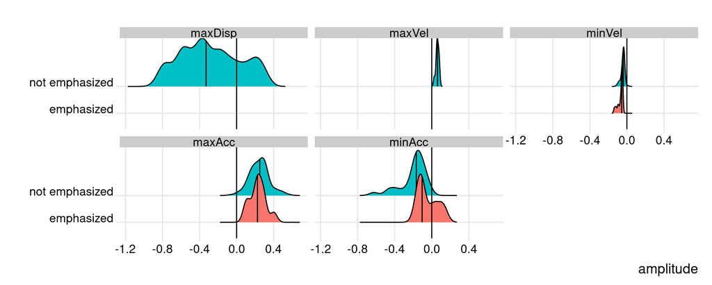

# Part 3: Amplitude of the signal at the AVO (all data included)

#### Figure 7. Amplitude at the AVO relative to emphasis

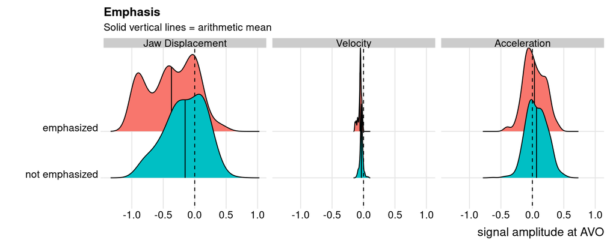

#### Figure 8. Amplitude at the AVO relative to emphasis and speaker

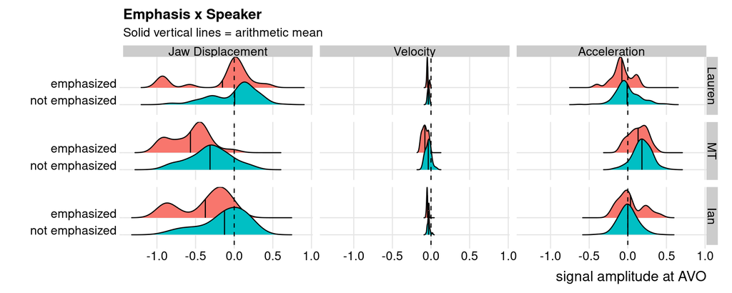

#### Figure 9. Amplitude at the AVO relative to word (only emphasized occurances)

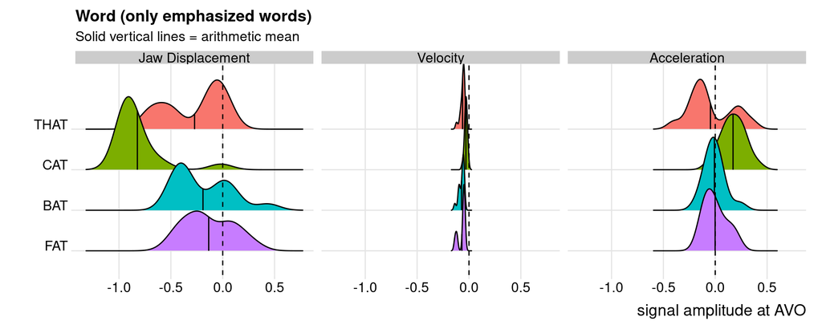

# Part 4: Inferential tests

#### (A) The following are Kruskal-Wallis tests, one for each type of point, of distance from the AVO contrasting emphatic and non-emphatic items:

| point_type | .y. | n | statistic | df | p | method |
| --- | --- | --- | --- | --- | --- | --- |
| maxDisp | distance | 752 | 26.02 | 1 | 3.38e-07 | Kruskal-Wallis |
| maxVel | distance | 752 | 6.307 | 1 | 0.012 | Kruskal-Wallis |
| minVel | distance | 752 | 1.125 | 1 | 0.289 | Kruskal-Wallis |
| maxAcc | distance | 752 | 15.22 | 1 | 9.56e-05 | Kruskal-Wallis |
| minAcc | distance | 752 | 0.005545 | 1 | 0.941 | Kruskal-Wallis |

#### (B) Same tests as above, but without Mark

| point_type | .y. | n | statistic | df | p | method |
| --- | --- | --- | --- | --- | --- | --- |
| maxDisp | distance | 466 | 8.019 | 1 | 0.00463 | Kruskal-Wallis |
| maxVel | distance | 466 | 1.067 | 1 | 0.302 | Kruskal-Wallis |
| minVel | distance | 466 | 0.994 | 1 | 0.319 | Kruskal-Wallis |
| maxAcc | distance | 466 | 7.065 | 1 | 0.00786 | Kruskal-Wallis |
| minAcc | distance | 466 | 0.4157 | 1 | 0.519 | Kruskal-Wallis |

#### (C) Kruskal-Wallis tests of the amplitudes at the AVO contrasting emphasis conditions:

| signal | .y. | n | statistic | df | p | method |
| --- | --- | --- | --- | --- | --- | --- |
| Jaw Displacement | value | 752 | 18.82 | 1 | 1.43e-05 | Kruskal-Wallis |
| Velocity | value | 752 | 36.88 | 1 | 1.26e-09 | Kruskal-Wallis |
| Acceleration | value | 752 | 2.389 | 1 | 0.122 | Kruskal-Wallis |

#### (D) The following is a table reporting many Wilcoxon tests regarding the distance of the point from the AVO. Each test contrasts each pair of words.

| point_type | .y. | group1 | group2 | n1 | n2 | statistic | p | p.adj | p.adj.signif |
| --- | --- | --- | --- | --- | --- | --- | --- | --- | --- |
| maxDisp | distance | THAT | CAT | 15 | 17 | 199.5 | 0.007 | 0.028 | * |
| maxDisp | distance | THAT | BAT | 15 | 15 | 67.5 | 0.065 | 0.129 | ns |
| maxDisp | distance | THAT | FAT | 15 | 15 | 165.5 | 0.029 | 0.088 | ns |
| maxDisp | distance | CAT | BAT | 17 | 15 | 22 | 7.3e-05 | 0.000438 | *** |
| maxDisp | distance | CAT | FAT | 17 | 15 | 91.5 | 0.18 | 0.18 | ns |
| maxDisp | distance | BAT | FAT | 15 | 15 | 191 | 0.001 | 0.006 | ** |
| maxVel | distance | THAT | CAT | 15 | 17 | 49 | 0.003 | 0.019 | * |
| maxVel | distance | THAT | BAT | 15 | 15 | 146.5 | 0.164 | 0.656 | ns |
| maxVel | distance | THAT | FAT | 15 | 15 | 82.5 | 0.221 | 0.656 | ns |
| maxVel | distance | CAT | BAT | 17 | 15 | 198 | 0.007 | 0.035 | * |
| maxVel | distance | CAT | FAT | 17 | 15 | 164 | 0.174 | 0.656 | ns |
| maxVel | distance | BAT | FAT | 15 | 15 | 82.5 | 0.221 | 0.656 | ns |
| minVel | distance | THAT | CAT | 15 | 17 | 246 | 8.27e-06 | 4.96e-05 | **** |
| minVel | distance | THAT | BAT | 15 | 15 | 136 | 0.339 | 1 | ns |
| minVel | distance | THAT | FAT | 15 | 15 | 111.5 | 0.983 | 1 | ns |
| minVel | distance | CAT | BAT | 17 | 15 | 13 | 1.66e-05 | 6.64e-05 | **** |
| minVel | distance | CAT | FAT | 17 | 15 | 11 | 1.18e-05 | 5.9e-05 | **** |
| minVel | distance | BAT | FAT | 15 | 15 | 94 | 0.455 | 1 | ns |
| maxAcc | distance | THAT | CAT | 15 | 17 | 227.5 | 0.000171 | 0.000855 | *** |
| maxAcc | distance | THAT | BAT | 15 | 15 | 87.5 | 0.309 | 0.618 | ns |
| maxAcc | distance | THAT | FAT | 15 | 15 | 128 | 0.534 | 0.618 | ns |
| maxAcc | distance | CAT | BAT | 17 | 15 | 25 | 0.000117 | 0.000702 | *** |
| maxAcc | distance | CAT | FAT | 17 | 15 | 49 | 0.003 | 0.013 | * |
| maxAcc | distance | BAT | FAT | 15 | 15 | 153 | 0.097 | 0.29 | ns |
| minAcc | distance | THAT | CAT | 15 | 17 | 138 | 0.706 | 1 | ns |
| minAcc | distance | THAT | BAT | 15 | 15 | 157.5 | 0.065 | 0.389 | ns |
| minAcc | distance | THAT | FAT | 15 | 15 | 122 | 0.709 | 1 | ns |
| minAcc | distance | CAT | BAT | 17 | 15 | 116 | 0.678 | 1 | ns |
| minAcc | distance | CAT | FAT | 17 | 15 | 112 | 0.571 | 1 | ns |
| minAcc | distance | BAT | FAT | 15 | 15 | 72.5 | 0.101 | 0.505 | ns |

#### (E) And now the same type of table but regarding not the distance from the AVO but the amplitude of the signal at the AVO:

| signal | .y. | group1 | group2 | n1 | n2 | statistic | p | p.adj | p.adj.signif |
| --- | --- | --- | --- | --- | --- | --- | --- | --- | --- |
| Jaw Displacement | value | THAT | CAT | 15 | 17 | 239 | 2.76e-05 | 0.00011 | *** |
| Jaw Displacement | value | THAT | BAT | 15 | 15 | 88 | 0.325 | 0.789 | ns |
| Jaw Displacement | value | THAT | FAT | 15 | 15 | 85 | 0.263 | 0.789 | ns |
| Jaw Displacement | value | CAT | BAT | 17 | 15 | 10 | 9.93e-06 | 4.99e-05 | **** |
| Jaw Displacement | value | CAT | FAT | 17 | 15 | 9 | 8.32e-06 | 4.99e-05 | **** |
| Jaw Displacement | value | BAT | FAT | 15 | 15 | 94 | 0.455 | 0.789 | ns |
| Velocity | value | THAT | CAT | 15 | 17 | 11.5 | 1.26e-05 | 6.3e-05 | **** |
| Velocity | value | THAT | BAT | 15 | 15 | 144.5 | 0.191 | 0.573 | ns |
| Velocity | value | THAT | FAT | 15 | 15 | 100 | 0.618 | 0.618 | ns |
| Velocity | value | CAT | BAT | 17 | 15 | 248 | 5.67e-06 | 3.4e-05 | **** |
| Velocity | value | CAT | FAT | 17 | 15 | 240.5 | 2.1e-05 | 8.4e-05 | **** |
| Velocity | value | BAT | FAT | 15 | 15 | 80.5 | 0.191 | 0.573 | ns |
| Acceleration | value | THAT | CAT | 15 | 17 | 52.5 | 0.005 | 0.02 | * |
| Acceleration | value | THAT | BAT | 15 | 15 | 79.5 | 0.178 | 0.534 | ns |
| Acceleration | value | THAT | FAT | 15 | 15 | 81 | 0.198 | 0.534 | ns |
| Acceleration | value | CAT | BAT | 17 | 15 | 225 | 9.18e-05 | 0.000551 | *** |
| Acceleration | value | CAT | FAT | 17 | 15 | 221 | 0.000201 | 0.001 | ** |
| Acceleration | value | BAT | FAT | 15 | 15 | 115 | 0.935 | 0.935 | ns |